# RSM_code

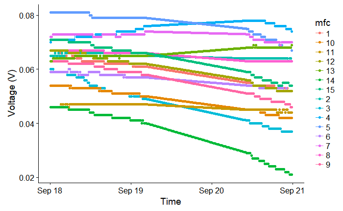

```r
voltage_data <- bind_rows(paddedTime,voltage_data) # bind together - this is where it goes wrong. Times and dateTimes no longer match.
voltage_data[1:89,1] <- voltage_data[1:89,1] - 7*60*60 #workaround
voltage_data <- voltage_data[order(voltage_data$dateTime),]
# fill with polynomial interpolation
packages(zoo)
voltage_data[,c(4:ncol(voltage_data))] <- na.approx(voltage_data[,c(4:ncol(voltage_data))])
#visualize
# between 2017-09-19 04:32:22 and 2017-09-20 10:21:51
test <- voltage_data[voltage_data$dateTime > as.Date("2017-09-18") & voltage_data$dateTime < as.Date("2017-09-21"),]
test_melt <- gather(test,"mfc","voltage",4:ncol(voltage_data))
#Visualize
ggplot(data=test_melt, aes(x = dateTime,y = voltage, group=mfc)) +
  geom_line(aes(color=mfc))+
  geom_point(aes(color=mfc))+
  xlab("Time")+
  ylab("Voltage (V)")
```

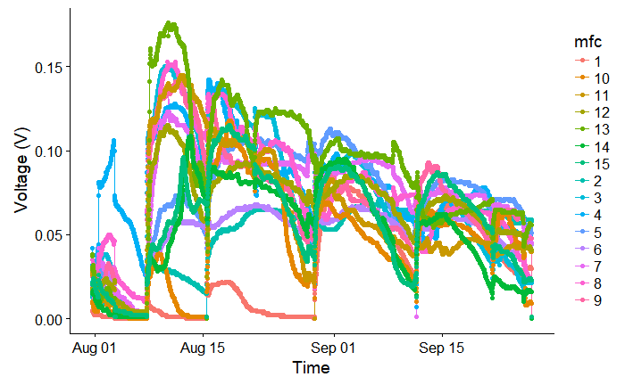

```r
# Visualize whole data set
test_melt <- gather(voltage_data,"mfc","voltage",4:ncol(voltage_data))
ggplot(data=test_melt, aes(x = dateTime,y = voltage, group=mfc)) +
  geom_line(aes(color=mfc))+
  geom_point(aes(color=mfc))+
  xlab("Time")+
  ylab("Voltage (V)")
```

```r
# nice work!
```

Now let’s apply cycle numbers to the voltage_data set to calculate power production over each cycle and MFC as well as coulombic efficiency for each cycle and MFC.

```r
# Find points in voltage_data where voltage is 0, use those as time points for marking distinct cycles
cycleTimes$end <- as.POSIXct(c("2017-08-07 15:52:22", "2017-08-15 11:12:22", "2017-08-29 10:52:22", "2017-09-11 15:32:22", "2017-09-26 16:01:51"))
#lookup
voltage_data <- cbind(voltage_data,cycleTimes[match(voltage_data$dateTime,cycleTimes$end),"cycle"])
voltage_data[!is.na(voltage_data$cycle),]
```

|  | dateTime | Date | Time | 1 | 2 | 3 | 4 | 5 | 6 | 7 | 8 | 9 | 10 | 11 | 12 | 13 | 14 | 15 | cycle |
| --- | --- | --- | --- | --- | --- | --- | --- | --- | --- | --- | --- | --- | --- | --- | --- | --- | --- | --- | --- |
| 530 | 2017-08-07 22:52:22 | 2017-08-07 | 22:52:22 | 0.009 | 0.027 | 0.106 | 0.107 | 0.031 | 0.028 | 0.044 | 0.103 | 0.089 | 0.026 | 0.107 | 0.074 | 0.054 | 0.032 | 0.031 | 1 |
| 1092 | 2017-08-15 18:12:22 | 2017-08-15 | 18:12:22 | 0.016 | 0.040 | 0.121 | 0.142 | 0.071 | 0.057 | 0.087 | 0.126 | 0.112 | 0.094 | 0.111 | 0.073 | 0.106 | 0.081 | 0.092 | 2 |
| 2099 | 2017-08-29 17:52:22 | 2017-08-29 | 17:52:22 | 0.032 | 0.060 | 0.079 | 0.090 | 0.100 | 0.062 | 0.091 | 0.065 | 0.059 | 0.060 | 0.059 | 0.074 | 0.094 | 0.082 | 0.065 | 3 |
| 3049 | 2017-09-11 22:32:22 | 2017-09-11 | 22:32:22 | 0.051 | 0.061 | 0.051 | 0.068 | 0.062 | 0.059 | 0.080 | 0.051 | 0.065 | 0.049 | 0.043 | 0.067 | 0.074 | 0.056 | 0.065 | 4 |

```r
voltage_data$cycle[nrow(voltage_data)] <- 5
# fill up
voltage_data$cycle <- as.numeric(voltage_data$cycle)
voltage_data %>% fill(cycle, .direction = "up") -> voltage_data
# move
voltage_data <- select(voltage_data,dateTime,cycle,everything())
#remove date and time because it seems to just be causing issues
voltage_data <- select(voltage_data,everything(),-Date,-Time)
```

Next let’s calculate power production for each mfc for each cycle. Then we can do some analysis on that before moving to coulombic efficiency.

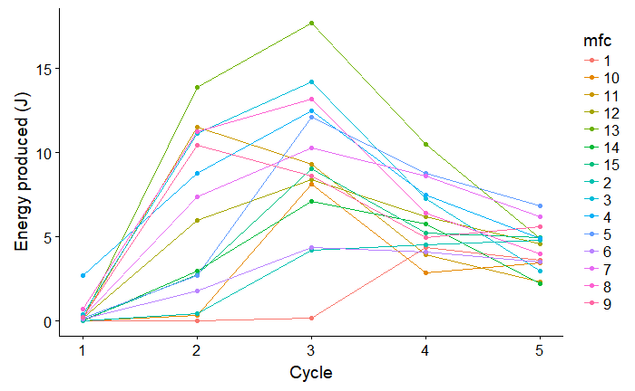

```r
voltage_melt <- gather(voltage_data,"mfc","voltage",3:ncol(voltage_data))
power_melt <- voltage_melt
power_melt <- power_melt[,-ncol(power_melt)]
power_melt$power_J_s <- voltage_melt$voltage^2/resistance
power_melt <- as.tibble(power_melt)
#integrate for power output or energy in Joules
packages(plyr)
power_output <- ddply(power_melt, .(cycle, mfc), summarize, energy_J = trapz(as.numeric(dateTime),power_J_s))
#check it worked
# it did - checked in excel
#visualize
ggplot(data=power_output, aes(x = cycle,y = energy_J, group=mfc)) +
  geom_line(aes(color=mfc))+
  geom_point(aes(color=mfc))+
  xlab("Cycle")+
  ylab("Energy produced (J)")
```

```r
#analysis
power_output %>% lm(energy_J~cycle*mfc,.) %>% anova()
```

```
Analysis of Variance Table

Response: energy_J
          Df Sum Sq Mean Sq F value  Pr(>F)
cycle      1  93.87  93.870  4.9397 0.03132 *
mfc       14 326.69  23.335  1.2279 0.28968
cycle:mfc 14  47.16   3.368  0.1773 0.99947
Residuals 45 855.14  19.003
---
Signif. codes:  0 ‘***’ 0.001 ‘**’ 0.01 ‘*’ 0.05 ‘.’ 0.1 ‘ ’ 1
```

```r
#cycle seems highly signficant
power_output %>% lm(energy_J~cycle,.) %>% anova()
```

```
Analysis of Variance Table

Response: energy_J
          Df  Sum Sq Mean Sq F value  Pr(>F)
cycle      1   93.87  93.870  5.5757 0.02088 *
Residuals 73 1228.99  16.835
---
Signif. codes:  0 ‘***’ 0.001 ‘**’ 0.01 ‘*’ 0.05 ‘.’ 0.1 ‘ ’ 1
```

```r
summary(aov(energy_J~as.factor(cycle),data=power_output))
```

```
                 Df Sum Sq Mean Sq F value   Pr(>F)
as.factor(cycle)  4  637.3  159.31   16.27 1.83e-09 ***
Residuals        70  685.6    9.79
---
Signif. codes:  0 ‘***’ 0.001 ‘**’ 0.01 ‘*’ 0.05 ‘.’ 0.1 ‘ ’ 1
```

```r
TukeyHSD(aov(energy_J~as.factor(cycle),data=power_output))
```

```
  Tukey multiple comparisons of means
    95% family-wise confidence level

Fit: aov(formula = energy_J ~ as.factor(cycle), data = power_output)

$`as.factor(cycle)`
          diff          lwr         upr     p adj
2-1  5.7414449  2.541518693  8.94137107 0.0000359
3-1  8.9323433  5.732417133 12.13226951 0.0000000
4-1  5.7064325  2.506506293  8.90635867 0.0000404
5-1  3.9728769  0.772950703  7.17280308 0.0075802
3-2  3.1908984 -0.009027747  6.39082463 0.0510038
4-2 -0.0350124 -3.234938587  3.16491379 0.9999998
5-2 -1.7685680 -4.968494177  1.43135820 0.5355879
4-3 -3.2259108 -6.425837027 -0.02598465 0.0472054
5-3 -4.9594664 -8.159392617 -1.75954024 0.0004414
5-4 -1.7335556 -4.933481777  1.46637060 0.5551155
```

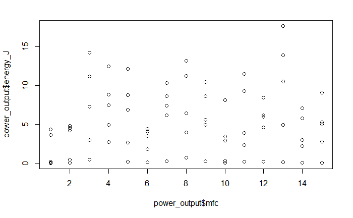

```r
#mfc doesn't have a significant effect on power output
plot(power_output$mfc,power_output$energy_J)
```

```r
summary(aov(energy_J~mfc,data=power_output))
```

```
            Df Sum Sq Mean Sq F value Pr(>F)
mfc         14  326.7   23.34   1.405  0.179
Residuals   60  996.2   16.60
```

```r
#fit power output for each cycle to response surface
power_output %>% spread(.,cycle,energy_J) -> power_output_spread
power_output_spread[order(as.numeric(power_output_spread$mfc)),] -> power_output_spread
cbind(rsm_cols,power_output_spread[,-1])->power_output_rsm
# Create blank matrix to fill in with p values
all_p_values <- as.data.frame(matrix(NA,ncol(power_output_rsm)-4,7))
packages(broom)
# Start loop
for(i in 5:ncol(power_output_rsm)){
model <- rsm(power_output_rsm[,i] ~ SO(temp, acetate), data = power_output_rsm)
all_p_values[i-4,] <- c(colnames(power_output_rsm)[i],as.numeric(tidy(model)$p.value)) # get coefficient table as a data frame https://stackoverflow.com/questions/31570440/extract-regression-p-value-in-r
}
#End Loop
# Append column names
colnames(all_p_values) <- c("Time",tidy(model)$term)
all_p_values
```

| Time | (Intercept) | temp | acetate | temp:acetate | temp^2 | acetate^2 |
| --- | --- | --- | --- | --- | --- | --- |
| 1 | 0.78254536166 | 0.00115580115324343 | 0.0175424872110988 | 0.00636727967491868 | 0.0290586543695173 | 0.279642884443296 |
| 2 | 0.00162148619322481 | 0.0216562672141612 | 0.939587247373416 | 0.752763219640689 | 0.987022646974139 | 0.38219948613254 |
| 3 | 1.08976419144824e-05 | 0.00260640927734092 | 0.847763432375431 | 0.373194150675529 | 0.292449191463511 | 0.984406473424706 |
| 4 | 4.71188497761809e-05 | 0.150383684446335 | 0.91867400571754 | 0.991616366775698 | 0.292355068110297 | 0.171129828748779 |
| 5 | 2.51990905477206e-05 | 0.995866434307806 | 0.685486806989154 | 0.79821843274591 | 0.198865858318348 | 0.132270918995739 |

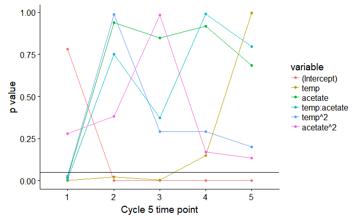

```r
# Turn character into numbers
all_p_values[,2:7] <- as.numeric(unlist(all_p_values[,2:7]))
#Reshape
packages(reshape2)
all_p_values <- melt(all_p_values)
# Plot
ggplot(data=all_p_values, aes(Time,value, group=variable)) +
  geom_line(aes(color=variable))+
  geom_point(aes(color=variable))+
  xlab("Cycle 5 time point")+
  ylab("p value")+
  geom_hline(yintercept = .05)
```

```r
#What about cycle 5? Power output in joules was not significant.
rsm(power_output_rsm[,"5"] ~ SO(temp, acetate), data = power_output_rsm) %>% tidy()
```

| term | estimate | std.error | statistic | p.value |
| --- | --- | --- | --- | --- |
| (Intercept) | 4.147871403 | 0.5269824 | 7.870986218 | 2.519909e-05 |
| temp | -0.003051027 | 0.5728220 | -0.005326309 | 9.958664e-01 |
| acetate | 0.232245408 | 0.5551268 | 0.418364645 | 6.854868e-01 |
| temp:acetate | 0.184749003 | 0.7015608 | 0.263339957 | 7.982184e-01 |
| temp^2 | -1.125110864 | 0.8112600 | -1.386868335 | 1.988659e-01 |
| acetate^2 | 1.396985183 | 0.8440041 | 1.655187748 | 1.322709e-01 |

```r
#fit cumulative power to response surface
power_output_rsm$cumulative <- rowSums(power_output_rsm[,5:9])
rsm <- rsm(power_output_rsm[,"cumulative"] ~ SO(temp, acetate), data = power_output_rsm)
summary(rsm)
```

```
Call:
rsm(formula = power_output_rsm[, "cumulative"] ~ SO(temp, acetate),
    data = power_output_rsm)

             Estimate Std. Error t value  Pr(>|t|)
(Intercept)  27.17260    3.35531  8.0984 2.007e-05 ***
temp         11.96338    3.64717  3.2802  0.009527 **
acetate       0.13876    3.53451  0.0393  0.969540
temp:acetate -1.37412    4.46686 -0.3076  0.765367
temp^2       -3.96692    5.16531 -0.7680  0.462165
acetate^2     1.12381    5.37380  0.2091  0.839005
---
Signif. codes:  0 ‘***’ 0.001 ‘**’ 0.01 ‘*’ 0.05 ‘.’ 0.1 ‘ ’ 1

Multiple R-squared:  0.5603,    Adjusted R-squared:  0.3159
F-statistic: 2.293 on 5 and 9 DF,  p-value: 0.132

Analysis of Variance Table

Response: power_output_rsm[, "cumulative"]
                   Df Sum Sq Mean Sq F value  Pr(>F)
FO(temp, acetate)   2 859.54  429.77  5.3848 0.02898
TWI(temp, acetate)  1   7.55    7.55  0.0946 0.76537
PQ(temp, acetate)   2  48.05   24.03  0.3010 0.74723
Residuals           9 718.30   79.81
Lack of fit         4 166.21   41.55  0.3763 0.81753
Pure error          5 552.09  110.42

Stationary point of response surface:
     temp   acetate
1.3731835 0.7777783

Eigenanalysis:
$values
[1]  1.214909 -4.058018

$vectors
              [,1]       [,2]
temp     0.1314397 -0.9913242
acetate -0.9913242 -0.1314397
```

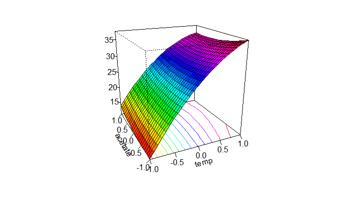

```r
persp(rsm, ~ temp + acetate, col = rainbow(50), contours = "colors")
```

Note that temperature has a highly significant effect on cumulative power output across all cycles.

Next let’s try transforming the power output data and seeing if results differ.

```r
# #visualize
# hist(power_output$energy_J)
# packages(ggpubr)
# ggqqplot(power_output$energy_J)
# shapiro.test(power_output$energy_J) # if p<.05, reject null hypothesis that data is normal, there is evidence data not normal
# #preprocess
# packages(caret)
# packages(e1071)
# trans = preProcess(data.frame(power_output[,"energy_J"]), c("BoxCox", "center", "scale"))
# power_trans = data.frame(trans = predict(trans, data.frame(power_output[,"energy_J"])))
# # Visualize again
# hist(unlist(power_trans))
# ggqqplot(unlist(power_trans))
# shapiro.test(unlist(power_trans))
# # Attach transformed variables to data set
# colnames(power_trans) <- "energy_J"
# power_output <- cbind(power_output[,-ncol(power_output)],power_trans)
```

Redo analysis with transformed variables

```r
# #analysis
# power_output %>% lm(energy_J~cycle*mfc,.) %>% anova()
# #cycle seems highly signficant
# power_output %>% lm(energy_J~cycle,.) %>% anova()
# summary(aov(energy_J~as.factor(cycle),data=power_output))
# TukeyHSD(aov(energy_J~as.factor(cycle),data=power_output))
# #mfc doesn't have a significant effect on power output
# plot(power_output$mfc,power_output$energy_J)
# summary(aov(energy_J~mfc,data=power_output))
# #fit power output for each cycle to response surface
# power_output %>% spread(.,cycle,energy_J) -> power_output_spread
# power_output_spread[order(as.numeric(power_output_spread$mfc)),] -> power_output_spread
# cbind(rsm_cols,power_output_spread[,-1])->power_output_rsm
#
# # Create blank matrix to fill in with p values
# all_p_values <- as.data.frame(matrix(NA,ncol(power_output_rsm)-4,7))
# packages(broom)
#
# # Start loop
# for(i in 5:ncol(power_output_rsm)){
# model <- rsm(power_output_rsm[,i] ~ SO(temp, acetate), data = power_output_rsm)
# all_p_values[i-4,] <- c(colnames(power_output_rsm)[i],as.numeric(tidy(model)$p.value)) # get coefficient table as a data frame https://stackoverflow.com/questions/31570440/extract-regression-p-value-in-r
# }
# #End Loop
#
# # Append column names
# colnames(all_p_values) <- c("Time",tidy(model)$term)
# all_p_values
#
# # Turn character into numbers
# all_p_values[,2:7] <- as.numeric(unlist(all_p_values[,2:7]))
#
# #Reshape
# packages(reshape2)
# all_p_values <- melt(all_p_values)
#
# # Plot
# ggplot(data=all_p_values, aes(Time,value, group=variable)) +
#   geom_line(aes(color=variable))+
#   geom_point(aes(color=variable))+
#   xlab("Cycle 5 time point")+
#   ylab("p value")+
#   geom_hline(yintercept = .05)
#
# #What about cycle 5? Power output in joules was not significant.
# rsm(power_output_rsm[,"5"] ~ SO(temp, acetate), data = power_output_rsm) %>% summary()
# #fit cumulative power to response surface
# power_output_rsm$cumulative <- rowSums(power_output_rsm[,5:9])
# rsm <- rsm(power_output_rsm[,"cumulative"] ~ SO(temp, acetate), data = power_output_rsm)
# summary(rsm)
# persp(rsm, ~ temp + acetate, col = rainbow(50), contours = "colors")
```

Next let’s work on coulombic efficiency calculation and analysis.

```r
#desired output: long format table "ce_long" with columns cycle, mfc, ce
#inputs: COD reduction, current = voltage/resistance
voltage_melt %>% mutate(current_A=voltage/resistance) %>% select(everything(),-voltage) -> current_melt
current_output <- ddply(current_melt, .(cycle, mfc), summarize, charge_C = trapz(as.numeric(dateTime),current_A))
#using dplyr
  # current_melt %>% group_by(cycle,mfc) %>% select(dateTime,current_A) %>% summarise_each(funs(charge_C=trapz(as.numeric(dateTime),current_A)))
current_output$mfc <- as.numeric(current_output$mfc)
current_output[with(current_output, order(current_output$cycle,current_output$mfc)),] %>% select(mfc,everything()) -> current_output
#calc CE = (M*Idt)/(F*b*van*COD_Reduction_gL)
M=  32
F=  96485.33289
b=  4
van=    0.03
mgL_gL= .001
current_output %>% mutate(ce = (M*charge_C)/(F*b*van*cod$delta_cod_mg_L*mgL_gL)) -> current_output
```

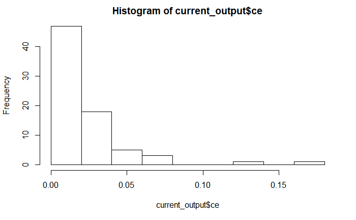

```r
#visualize
hist(current_output$ce)
```

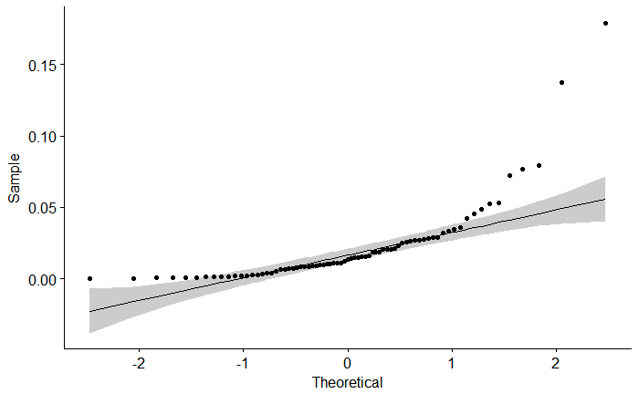

```r
packages(ggpubr)
ggqqplot(current_output$ce)
```

```r
shapiro.test(current_output$ce) # if p<.05, reject null hypothesis that data is normal, there is evidence data not normal
```

```
    Shapiro-Wilk normality test

data:  current_output$ce
W = 0.64835, p-value = 4.093e-12
```

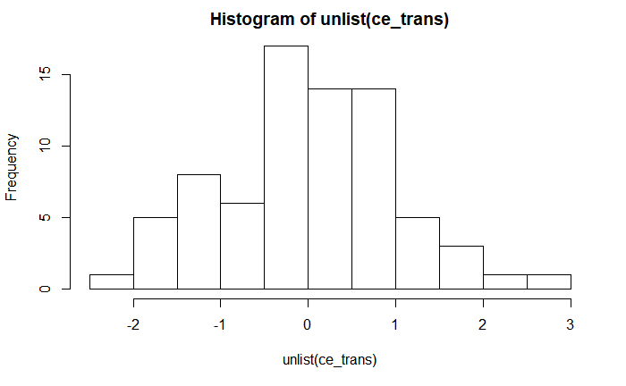

```r
#preprocess
packages(caret)
packages(e1071)
trans = preProcess(data.frame(current_output[,"ce"]), c("BoxCox", "center", "scale"))
ce_trans = data.frame(trans = predict(trans, data.frame(current_output[,"ce"])))
# Visualize again
hist(unlist(ce_trans))
```

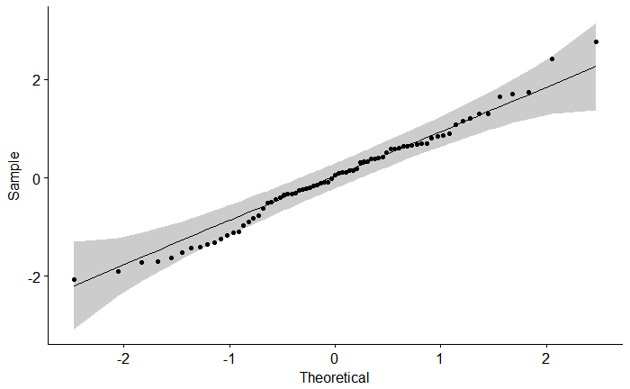

```r
ggqqplot(unlist(ce_trans))
```

```r
shapiro.test(unlist(ce_trans))
```

```
    Shapiro-Wilk normality test

data:  unlist(ce_trans)
W = 0.98591, p-value = 0.5744
```

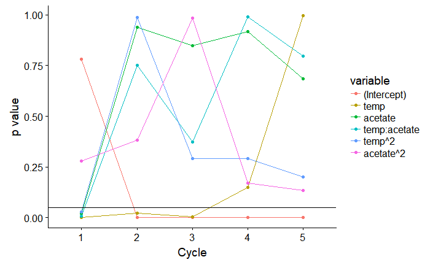

```r
# Attach transformed variables to data set
colnames(ce_trans) <- "ce_trans"
current_output <- cbind(current_output,ce_trans)
#fit data for each cycle to response surface
current_output -> data
data %>% select(mfc,cycle,ce_trans) %>% spread(.,cycle,ce_trans) -> data_spread
data_spread[order(as.numeric(data_spread$mfc)),] -> data_spread
cbind(rsm_cols,power_output_spread[,-1]) -> data_rsm
# Create blank matrix to fill in with p values
all_p_values <- as.data.frame(matrix(NA,ncol(data_rsm)-4,7))
packages(broom)
# Start loop
for(i in 5:ncol(data_rsm)){
model <- rsm(data_rsm[,i] ~ SO(temp, acetate), data = data_rsm)
all_p_values[i-4,] <- c(colnames(data_rsm)[i],as.numeric(tidy(model)$p.value)) # get coefficient table as a data frame https://stackoverflow.com/questions/31570440/extract-regression-p-value-in-r
}
#End Loop
# Append column names
colnames(all_p_values) <- c("cycle",tidy(model)$term)
# Turn character into numbers
all_p_values[,2:7] <- as.numeric(unlist(all_p_values[,2:7]))
#Reshape
packages(reshape2)
all_p_values <- melt(all_p_values)
# Plot
ggplot(data=all_p_values, aes(cycle,value, group=variable)) +
  geom_line(aes(color=variable))+
  geom_point(aes(color=variable))+
  xlab("Cycle")+
  ylab("p value")+
  geom_hline(yintercept = .05)
```

Let’s try analyzing charge_C as well. Doesn’t fit well to our response surface.

```r
current_output %>% filter(cycle==5) %>% select(mfc,charge_C) -> data
trans = preProcess(data.frame(data %>% select(-1)), c("BoxCox", "center", "scale"))
data_trans = data.frame(trans = predict(trans, data.frame(data %>% select(-1))))
colnames(data_trans) <- paste("trans_",colnames(data_trans),sep = "")
# # Visualize again
# data_trans %>% apply(.,2,hist)
# data_trans %>% apply(.,2,ggqqplot)
# data_trans %>% apply(.,2,shapiro.test)
# Attach transformed variables to data set
rsm_hist <- rsm_cols
rsm_hist <- cbind(rsm_hist,data_trans)
#fit data to response surface
rsm <- rsm(rsm_hist$trans_charge_C ~ SO(temp, acetate), data = rsm_hist)
summary(rsm)
```

```
Call:
rsm(formula = rsm_hist$trans_charge_C ~ SO(temp, acetate), data = rsm_hist)

              Estimate Std. Error t value Pr(>|t|)
(Intercept)  -0.138404   0.408164 -0.3391   0.7423
temp         -0.035472   0.443668 -0.0800   0.9380
acetate       0.195460   0.429963  0.4546   0.6602
temp:acetate  0.118509   0.543380  0.2181   0.8322
temp^2       -0.729560   0.628346 -1.1611   0.2755
acetate^2     0.962764   0.653707  1.4728   0.1749

Multiple R-squared:  0.2408,    Adjusted R-squared:  -0.181
F-statistic: 0.5708 on 5 and 9 DF,  p-value: 0.7216

Analysis of Variance Table

Response: rsm_hist$trans_charge_C
                   Df  Sum Sq Mean Sq F value Pr(>F)
FO(temp, acetate)   2  0.3005 0.15024  0.1272 0.8821
TWI(temp, acetate)  1  0.0562 0.05618  0.0476 0.8322
PQ(temp, acetate)   2  3.0139 1.50695  1.2759 0.3252
Residuals           9 10.6294 1.18105
Lack of fit         4  5.0945 1.27362  1.1505 0.4301
Pure error          5  5.5350 1.10700

Stationary point of response surface:
       temp     acetate
-0.03239340 -0.09951589

Eigenanalysis:
$values
[1]  0.9648362 -0.7316324

$vectors
              [,1]        [,2]
temp    0.03494937 -0.99938908
acetate 0.99938908  0.03494937
```

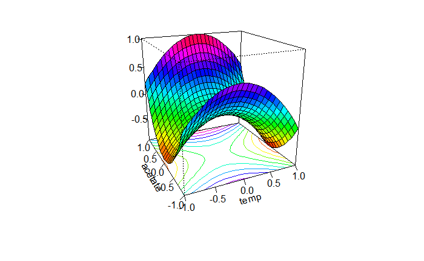

```r
persp(rsm, ~ temp + acetate, col = rainbow(50), contours = "colors")
```

IVIS Image data

```r
read_tsv('./IVIS/ivis_measurements.txt') -> ivis
ivis[ivis==""] <- NA #Convert blank values to NA
ivis[ivis=="N/A"] <- NA
ivis %>% select(which(colMeans(is.na(.)) < 0.5)) -> ivis #select columns with less than 50% NA
colnames(ivis) %>% str_replace_all(" ","_") -> colnames(ivis)
```

```r
# From JaeB Kim: In terms of the fluorescence unit, we recommend “Total Radiant Efficiency” than Avg Radiant Efficiency. Avg radiant efficiency considers pixel number in the calculation. Sometimes depending on how you draw ROI’s, the measurements may get affected. Total radiant efficiency is simply the sum of the signals in the ROI. That usually works in most cases including yours.
ivis %>% mutate(Channel = ifelse(EM_Filter==540,"SG","PI")) %>%  mutate(Side=unlist(str_extract_all(Comment1,"[a-z]"))) %>%
  mutate(mfc=unlist(str_extract_all(Comment1,"[0-9]{1,2}"))) %>%
  select(mfc,Side,Channel,`Total_Radiant_Efficiency_[p/s]_/_[uW/cm2]`) %>% spread(Channel,`Total_Radiant_Efficiency_[p/s]_/_[uW/cm2]`) -> data
#How much do front and back readings differ for the same MFC? When blocking by MFC, back fluorescence always higher!
anova(lm(PI~Side+mfc,data))
```

```
Analysis of Variance Table

Response: PI
          Df     Sum Sq    Mean Sq F value  Pr(>F)
Side       1 1.3541e+17 1.3541e+17  5.2839 0.03744 *
mfc       14 8.7411e+17 6.2436e+16  2.4363 0.05358 .
Residuals 14 3.5879e+17 2.5628e+16
---
Signif. codes:  0 ‘***’ 0.001 ‘**’ 0.01 ‘*’ 0.05 ‘.’ 0.1 ‘ ’ 1
```

```r
anova(lm(SG~Side+mfc,data))
```

```
Analysis of Variance Table

Response: SG
          Df     Sum Sq    Mean Sq F value   Pr(>F)
Side       1 8.6915e+17 8.6915e+17  7.2684 0.017393 *
mfc       14 6.5087e+18 4.6491e+17  3.8879 0.007977 **
Residuals 14 1.6741e+18 1.1958e+17
---
Signif. codes:  0 ‘***’ 0.001 ‘**’ 0.01 ‘*’ 0.05 ‘.’ 0.1 ‘ ’ 1
```

```r
  # summarize by finding mean of front and back
  ivis %>% mutate(Channel = ifelse(EM_Filter==540,"SG","PI")) %>%  mutate(Side=unlist(str_extract_all(Comment1,"[a-z]"))) %>%
  mutate(mfc=unlist(str_extract_all(Comment1,"[0-9]{1,2}"))) %>%
  select(mfc,Side,Channel,`Total_Radiant_Efficiency_[p/s]_/_[uW/cm2]`) %>% spread(Channel,`Total_Radiant_Efficiency_[p/s]_/_[uW/cm2]`) %>%         group_by(mfc) %>% summarise_each(funs(mean)) %>% select(-Side) %>% mutate("live/dead"=(SG-PI)/PI) %>% mutate_each(funs(as.numeric(.))) %>% arrange(mfc) -> ivis_data
```

Now let’s see if we can fit our fluorescence data to our response surface. Note that increasing temperatures decrease SG, PI, and the live/dead ratio. Additionally acetate^2 has a significant effect on SG and PI signals across the mfcs.

```r
data <- ivis_data
# #visualize
# data %>% select(-1) %>% apply(.,2,hist)
# data %>% select(-1) %>% apply(.,2,ggqqplot)
# data %>% select(-1) %>% apply(.,2,shapiro.test)
# shapiro.test(current_output$ce) # if p<.05, reject null hypothesis that data is normal, there is evidence data not normal
#preprocess
trans = preProcess(data.frame(data %>% select(-1)), c("BoxCox", "center", "scale"))
data_trans = data.frame(trans = predict(trans, data.frame(data %>% select(-1))))
# # Visualize again
# data_trans %>% apply(.,2,hist)
# data_trans %>% apply(.,2,ggqqplot)
# data_trans %>% apply(.,2,shapiro.test)
# Attach transformed variables to data set
rsm_hist <- cbind(rsm_hist,data_trans)
#fit data to response surface
rsm <- rsm(rsm_hist$trans.PI ~ SO(temp, acetate), data = rsm_hist)
summary(rsm)
```

```
Call:
rsm(formula = rsm_hist$trans.PI ~ SO(temp, acetate), data = rsm_hist)

              Estimate Std. Error t value Pr(>|t|)
(Intercept)  -0.679360   0.225798 -3.0087 0.014747 *
temp         -0.828061   0.245439 -3.3738 0.008207 **
acetate       0.314684   0.237857  1.3230 0.218463
temp:acetate  0.054157   0.300600  0.1802 0.861016
temp^2        0.411022   0.347603  1.1824 0.267325
acetate^2     1.139937   0.361633  3.1522 0.011696 *
---
Signif. codes:  0 ‘***’ 0.001 ‘**’ 0.01 ‘*’ 0.05 ‘.’ 0.1 ‘ ’ 1

Multiple R-squared:  0.7676,    Adjusted R-squared:  0.6386
F-statistic: 5.947 on 5 and 9 DF,  p-value: 0.0106

Analysis of Variance Table

Response: rsm_hist$trans.PI
                   Df Sum Sq Mean Sq F value   Pr(>F)
FO(temp, acetate)   2 4.5378 2.26892  6.2774 0.019640
TWI(temp, acetate)  1 0.0117 0.01173  0.0325 0.861016
PQ(temp, acetate)   2 6.1974 3.09872  8.5732 0.008236
Residuals           9 3.2530 0.36144
Lack of fit         4 1.0474 0.26184  0.5936 0.683255
Pure error          5 2.2056 0.44112

Stationary point of response surface:
      temp    acetate
 1.0180071 -0.1622089

Eigenanalysis:
$values
[1] 1.1409413 0.4100172

$vectors
              [,1]        [,2]
temp    0.03707244 -0.99931258
acetate 0.99931258  0.03707244
```

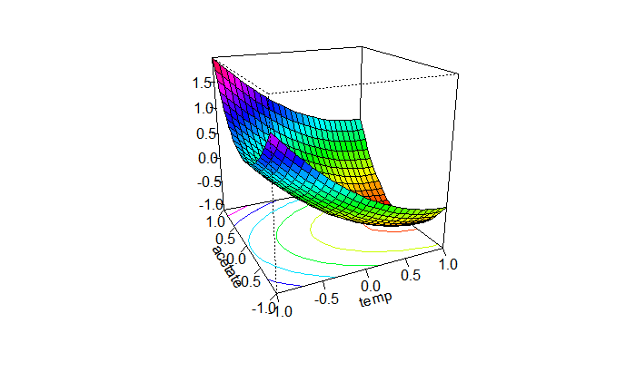

```r
persp(rsm, ~ temp + acetate, col = rainbow(50), contours = "colors")
```

```r
rsm <- rsm(rsm_hist$trans.SG ~ SO(temp, acetate), data = rsm_hist)
summary(rsm)
```

```
Call:
rsm(formula = rsm_hist$trans.SG ~ SO(temp, acetate), data = rsm_hist)

              Estimate Std. Error t value Pr(>|t|)
(Intercept)  -0.561502   0.232049 -2.4198  0.03863 *
temp         -0.995567   0.252234 -3.9470  0.00337 **
acetate       0.326799   0.244442  1.3369  0.21406
temp:acetate  0.073274   0.308922  0.2372  0.81782
temp^2        0.383540   0.357226  1.0737  0.31092
acetate^2     0.891459   0.371645  2.3987  0.03998 *
---
Signif. codes:  0 ‘***’ 0.001 ‘**’ 0.01 ‘*’ 0.05 ‘.’ 0.1 ‘ ’ 1

Multiple R-squared:  0.7546,    Adjusted R-squared:  0.6183
F-statistic: 5.535 on 5 and 9 DF,  p-value: 0.01329

Analysis of Variance Table

Response: rsm_hist$trans.SG
                   Df Sum Sq Mean Sq F value   Pr(>F)
FO(temp, acetate)   2 6.4425  3.2212  8.4385 0.008629
TWI(temp, acetate)  1 0.0215  0.0215  0.0563 0.817818
PQ(temp, acetate)   2 4.1004  2.0502  5.3709 0.029165
Residuals           9 3.4356  0.3817
Lack of fit         4 1.2734  0.3183  0.7362 0.605385
Pure error          5 2.1622  0.4324

Stationary point of response surface:
      temp    acetate
 1.3205600 -0.2375665

Eigenanalysis:
$values
[1] 0.8940885 0.3809106

$vectors
              [,1]        [,2]
temp    0.07157599 -0.99743515
acetate 0.99743515  0.07157599
```

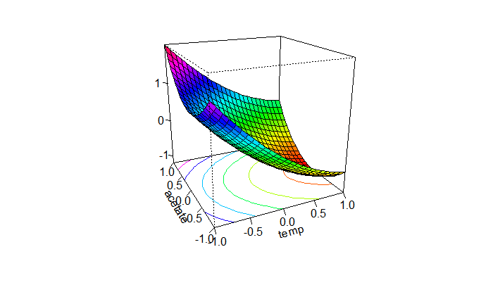

```r
persp(rsm, ~ temp + acetate, col = rainbow(50), contours = "colors")
```

```r
rsm <- rsm(rsm_hist$trans.live.dead ~ SO(temp, acetate), data = rsm_hist)
summary(rsm)
```

```
Call:
rsm(formula = rsm_hist$trans.live.dead ~ SO(temp, acetate), data = rsm_hist)

              Estimate Std. Error t value Pr(>|t|)
(Intercept)  -0.060249   0.355838 -0.1693  0.86929
temp         -0.926895   0.386791 -2.3964  0.04014 *
acetate       0.227576   0.374843  0.6071  0.55877
temp:acetate  0.149800   0.473720  0.3162  0.75905
temp^2       -0.234571   0.547793 -0.4282  0.67856
acetate^2     0.320551   0.569903  0.5625  0.58753
---
Signif. codes:  0 ‘***’ 0.001 ‘**’ 0.01 ‘*’ 0.05 ‘.’ 0.1 ‘ ’ 1

Multiple R-squared:  0.4229,    Adjusted R-squared:  0.1024
F-statistic: 1.319 on 5 and 9 DF,  p-value: 0.3376

Analysis of Variance Table

Response: rsm_hist$trans.live.dead
                   Df Sum Sq Mean Sq F value  Pr(>F)
FO(temp, acetate)   2 5.5041 2.75207  3.0659 0.09651
TWI(temp, acetate)  1 0.0898 0.08976  0.1000 0.75905
PQ(temp, acetate)   2 0.3273 0.16365  0.1823 0.83635
Residuals           9 8.0788 0.89764
Lack of fit         4 4.2681 1.06701  1.4000 0.35464
Pure error          5 3.8107 0.76215

Stationary point of response surface:
       temp     acetate
-1.94402742  0.09926504

Eigenanalysis:
$values
[1]  0.3304798 -0.2444995

$vectors
             [,1]       [,2]
temp    0.1314050 -0.9913288
acetate 0.9913288  0.1314050
```

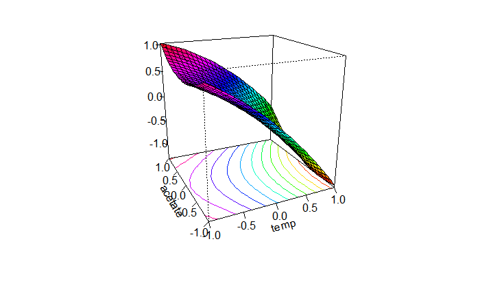

```r
persp(rsm, ~ temp + acetate, col = rainbow(50), contours = "colors")
```

Next, let’s do multivariate analysis on all the dependent variables in rsm_hist and see if any are significantly correlated.

```r
rsm_hist
```

| run | type | temp | acetate | trans_charge_C | trans.PI | trans.SG | trans.live.dead |
| --- | --- | --- | --- | --- | --- | --- | --- |
| 1 | corner | -1 | -1.0 | -0.5650323 | 1.52596784 | 1.47690379 | 0.4481369 |
| 2 | corner | -1 | 1.0 | 0.4803578 | 1.61537692 | 1.50290059 | 0.1557339 |
| 3 | corner | 1 | -1.0 | -1.0421442 | 0.09501389 | -0.29521580 | -0.8080806 |
| 4 | corner | 1 | 1.0 | 0.4772801 | 0.40105109 | 0.02387705 | -0.5012835 |
| 5 | edge | 0 | -1.0 | 1.7906800 | -0.26432634 | -0.29966310 | 0.1073772 |
| 6 | edge | -1 | 0.0 | -0.4872738 | 0.81769729 | 1.25592968 | 1.9334577 |
| 7 | edge | 0 | 1.0 | 1.3749295 | 0.84059696 | 0.89416563 | 0.9848526 |
| 8 | edge | 1 | 0.0 | -0.2199185 | -1.50539085 | -1.46632875 | -1.7146790 |
| 9 | center | 0 | 0.0 | 0.8805152 | -1.51879335 | -1.33888725 | -1.0395093 |
| 10 | center | 0 | 0.0 | -0.6160916 | -0.93482232 | -1.02598582 | -1.0480972 |

[output cut: 5 more lines]

```r
names(rsm_hist)[names(rsm_hist) == 'run'] <- 'mfc'
#Get delta COD
cod$mfc <- as.numeric(cod$mfc)
cod %>% filter(cycle==5) %>% select(mfc,delta_cod_mg_L,delta_cod_mg_L_day) %>% full_join(rsm_hist,.) -> rsm_hist
#Voltage
cycle_5_data[,"43003.56"] %>% cbind(gsub("X","",rownames(cycle_5_data,.))) %>% as_tibble() -> voltage
colnames(voltage) <- c("voltage","mfc")
voltage %>% mutate_all(as.numeric) %>% full_join(rsm_hist,.) -> rsm_hist
#Energy production
names(power_output_rsm)[names(power_output_rsm) == 'run'] <- 'mfc'
names(power_output_rsm)[names(power_output_rsm) == '5'] <- 'cycle_5_energy_J'
names(power_output_rsm)[names(power_output_rsm) == 'cumulative'] <- 'cumulative_energy_J'
power_output_rsm %>% select(mfc,cycle_5_energy_J,cumulative_energy_J) %>% full_join(rsm_hist,.) -> rsm_hist
#CE
current_output %>% filter(cycle==5) %>% arrange(mfc) %>% select(mfc,ce_trans) %>% full_join(rsm_hist,.) -> rsm_hist
names(rsm_hist)[names(rsm_hist) == 'ce_trans'] <- 'trans_ce'
#transform any untransformed
colnames(rsm_hist) <- str_replace_all(colnames(rsm_hist),"[.]","_")
rsm_hist %>% as_tibble() %>% select(-c(type,temp,acetate)) %>% select(-starts_with("trans")) -> data

trans = preProcess(data.frame(data %>% select(-1)), c("BoxCox", "center", "scale"))
data_trans = data.frame(trans = predict(trans, data.frame(data %>% select(-1))))
# Attach transformed variables to data set
rsm_hist <- cbind(rsm_hist,data_trans)
colnames(rsm_hist) <- str_replace_all(colnames(rsm_hist),"[.]","_")
rsm_hist %>% as_tibble() %>% select(-c(mfc,type,temp,acetate)) %>% select(starts_with("trans")) -> rsm_hist_trans
```

Now that we’ve got the data let’s do multivariate analysis. Note the p matrix isn’t symmetric for corr.test(…,adjust=“BH”)

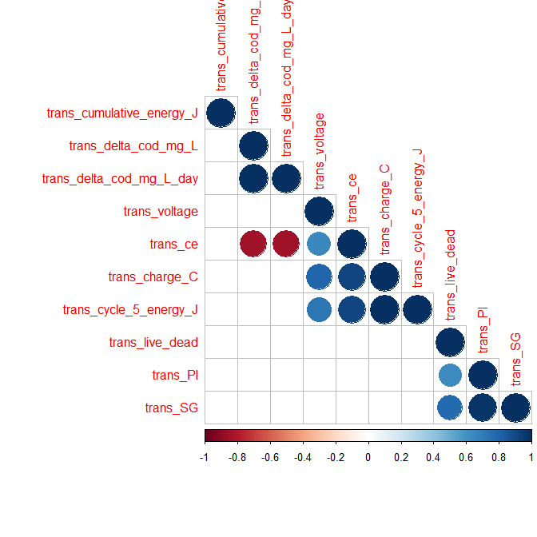

```r
# https://cran.r-project.org/web/packages/corrplot/vignettes/corrplot-intro.html
packages(psych)
corr.test(rsm_hist_trans,adjust = "none") -> trans_corr
#non-adjusted p value matrix is symmetric, BH is not
p.adjust(trans_corr$p,method = "BH") %>% matrix(.,nrow = nrow(trans_corr$r),ncol = ncol(trans_corr$r)) -> trans_corr$p
packages(corrplot)
packages(RColorBrewer)
corrplot(trans_corr$r, type = "lower", order = "hclust", p.mat = trans_corr$p, sig.level = 0.05, insig = "blank")
```

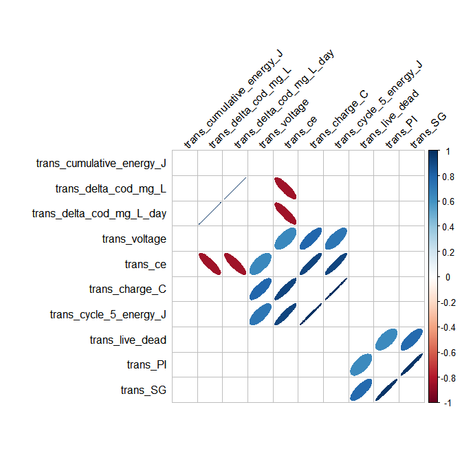

```r
#make diagonal excluded
diag(trans_corr$p) <- 1
corrplot(trans_corr$r, type = "full", method = "ellipse",order = "hclust", p.mat = trans_corr$p, sig.level = 0.05, insig = "blank",tl.col = "black", tl.srt = 45)
```

Let’s check and make sure we get the same BH values in JMP. Slightly different, but the same number of significant values.

```r
# lower.tri(trans_corr$p)*trans_corr$p -> data
# as.vector(data) -> data
# data <- data[data != 0]
# data[order(data)]->data
# data[data<=0.05]
```

What happens if we only select the center point replicates? Do we get better correlation? No.

```r
# rsm_hist %>% filter(type=="center") %>% select(starts_with("trans")) ->rsm_center_hist_trans
#
#
# corr.test(rsm_center_hist_trans,adjust = "none") -> trans_corr
# #non-adjusted p value matrix is symmetric, BH is not
# p.adjust(trans_corr$p,method = "BH") %>% matrix(.,nrow = nrow(trans_corr$r),ncol = ncol(trans_corr$r)) -> trans_corr$p
# packages(corrplot)
# packages(RColorBrewer)
# corrplot(trans_corr$r, type = "lower", order = "hclust", p.mat = trans_corr$p, sig.level = 0.05, insig = "blank")
#
# #make diagonal excluded
# diag(trans_corr$p) <- 1
# corrplot(trans_corr$r, type = "full", method = "ellipse",order = "hclust", p.mat = trans_corr$p, sig.level = 0.05, insig = "blank",tl.col = "black")
```

What if we do PCA/LDA? Not getting significant Wilks Lambda, so the results aren’t clustering too well based on type, temp, or acetate.

```r
# rsm_hist %>% select(mfc,type,temp,acetate,starts_with("trans")) -> data # doesn't look too promising in JMP
#
# # Wilks Lambda
# dep.vars <- cbind(data %>% select(-mfc,-type,-temp,-acetate))
# manova_fit <- manova(as.matrix(dep.vars) ~ data$type)
# summary(manova_fit, test="Wilks",tol = 0)
# manova_fit <- manova(as.matrix(dep.vars) ~ as.factor(data$temp))
# summary(manova_fit, test="Wilks",tol = 0)
# manova_fit <- manova(as.matrix(dep.vars) ~ as.factor(data$acetate))
# summary(manova_fit, test="Wilks",tol = 0)
```

Now let’s go back and see if we missed anything in our response surfaces. Let’s fit all the transformed variables to temp and acetate, with and without the validation points.

```r
# with validation points
# https://stackoverflow.com/questions/22713325/fitting-several-regression-models-with-dplyr
rsm_hist %>% select(mfc,type,temp,acetate,starts_with("trans"))  %>% gather("variable","value",c(5:ncol(.))) %>% group_by(variable) %>% do(fitVariable = rsm(value ~ SO(temp, acetate), data = .)) -> dfVariable
# get the coefficients by group in a tidy data_frame
dfVariableCoef = tidy(dfVariable, fitVariable)
dfVariableCoef
```

| variable | term | estimate | std.error | statistic | p.value |
| --- | --- | --- | --- | --- | --- |
| trans_ce | (Intercept) | -0.303876549 | 0.08038995 | -3.78003138 | 0.004348804 |
| trans_ce | temp | -0.025950077 | 0.08738268 | -0.29697049 | 0.773228820 |
| trans_ce | acetate | 0.016072373 | 0.08468331 | 0.18979388 | 0.853682215 |
| trans_ce | temp:acetate | 0.108089288 | 0.10702149 | 1.00997742 | 0.338886922 |
| trans_ce | temp^2 | -0.107521810 | 0.12375585 | -0.86882204 | 0.407516079 |
| trans_ce | acetate^2 | 0.231565916 | 0.12875087 | 1.79855801 | 0.105631456 |
| trans_charge_C | (Intercept) | -0.138404297 | 0.40816411 | -0.33908983 | 0.742319848 |
| trans_charge_C | temp | -0.035472389 | 0.44366830 | -0.07995250 | 0.938024636 |
| trans_charge_C | acetate | 0.195459534 | 0.42996276 | 0.45459643 | 0.660165606 |
| trans_charge_C | temp:acetate | 0.118508575 | 0.54338047 | 0.21809502 | 0.832219863 |

[output cut: 50 more lines]

```r
dfVariableCoef %>% filter(p.value<=.05,term != "(Intercept)")
```

| variable | term | estimate | std.error | statistic | p.value |
| --- | --- | --- | --- | --- | --- |
| trans_cumulative_energy_J | temp | 1.1075567 | 0.3376513 | 3.280179 | 0.009526552 |
| trans_live_dead | temp | -0.9268953 | 0.3867911 | -2.396372 | 0.040135909 |
| trans_PI | temp | -0.8280613 | 0.2454388 | -3.373799 | 0.008207336 |
| trans_PI | acetate^2 | 1.1399368 | 0.3616330 | 3.152192 | 0.011696217 |
| trans_SG | temp | -0.9955669 | 0.2522337 | -3.947001 | 0.003369992 |
| trans_SG | acetate^2 | 0.8914594 | 0.3716447 | 2.398687 | 0.039983865 |

```r
# get the predictions by group in a tidy data_frame - doesn't work
# dfVariablePred = augment(dfVariable,fitVariable)
# dfVariablePred
# get the summary statistics by group in a tidy data_frame
dfVariableSumm = glance(dfVariable, fitVariable)
dfVariableSumm
```

| variable | r.squared | adj.r.squared | sigma | statistic | p.value | df | logLik | AIC | BIC | deviance | df.residual |
| --- | --- | --- | --- | --- | --- | --- | --- | --- | --- | --- | --- |
| trans_ce | 0.3285506 | -0.04447688 | 0.2140430 | 0.8807678 | 0.53096900 | 6 | 5.670791 | 2.658418 | 7.61477 | 0.4123296 | 9 |
| trans_charge_C | 0.2407540 | -0.18104935 | 1.0867609 | 0.5707731 | 0.72164217 | 6 | -18.700911 | 51.401821 | 56.35817 | 10.6294441 | 9 |
| trans_cumulative_energy_J | 0.5602532 | 0.31594947 | 0.8270735 | 2.2932649 | 0.13196460 | 6 | -14.604960 | 43.209919 | 48.16627 | 6.1564547 | 9 |
| trans_cycle_5_energy_J | 0.2616722 | -0.14850987 | 1.0716855 | 0.6379416 | 0.67711040 | 6 | -18.491376 | 50.982752 | 55.93910 | 10.3365888 | 9 |
| trans_delta_cod_mg_L | 0.4694606 | 0.17471650 | 0.9084512 | 1.5927735 | 0.25609154 | 6 | -16.012673 | 46.025347 | 50.98170 | 7.4275515 | 9 |
| trans_delta_cod_mg_L_day | 0.4694606 | 0.17471650 | 0.9084512 | 1.5927735 | 0.25609154 | 6 | -16.012673 | 46.025347 | 50.98170 | 7.4275515 | 9 |
| trans_live_dead | 0.4229432 | 0.10235609 | 0.9474407 | 1.3192770 | 0.33761736 | 6 | -16.643022 | 47.286044 | 52.24240 | 8.0787951 | 9 |
| trans_PI | 0.7676449 | 0.63855871 | 0.6011999 | 5.9467631 | 0.01060398 | 6 | -9.820468 | 33.640937 | 38.59729 | 3.2529716 | 9 |
| trans_SG | 0.7546014 | 0.61826885 | 0.6178440 | 5.5350053 | 0.01329264 | 6 | -10.230095 | 34.460191 | 39.41654 | 3.4355803 | 9 |
| trans_voltage | 0.2121932 | -0.22547726 | 1.1070128 | 0.4848241 | 0.77992744 | 6 | -18.977864 | 51.955727 | 56.91208 | 11.0292953 | 9 |

I’m getting the same significant RSM terms in JMP, which is good. Code runs well so far.

```r
# without validation points
# https://stackoverflow.com/questions/22713325/fitting-several-regression-models-with-dplyr
rsm_hist %>% select(mfc,type,temp,acetate,starts_with("trans"))  %>% filter(type!="validation") %>% gather("variable","value",c(5:ncol(.))) %>% group_by(variable) %>% do(fitVariable = rsm(value ~ SO(temp, acetate), data = .)) -> dfVariable
# get the coefficients by group in a tidy data_frame
dfVariableCoef = tidy(dfVariable, fitVariable)
dfVariableCoef
```

| variable | term | estimate | std.error | statistic | p.value |
| --- | --- | --- | --- | --- | --- |
| trans_ce | (Intercept) | -0.262865810 | 0.07731618 | -3.39988085 | 0.011444343 |
| trans_ce | temp | -0.025950077 | 0.07601666 | -0.34137356 | 0.742840487 |
| trans_ce | acetate | 0.039392205 | 0.07601666 | 0.51820490 | 0.620287047 |
| trans_ce | temp:acetate | 0.108089288 | 0.09310101 | 1.16098939 | 0.283702651 |
| trans_ce | temp^2 | -0.146120152 | 0.11204179 | -1.30415756 | 0.233423364 |
| trans_ce | acetate^2 | 0.227947321 | 0.11204179 | 2.03448475 | 0.081372482 |
| trans_charge_C | (Intercept) | 0.147754553 | 0.38045386 | 0.38836392 | 0.709287961 |
| trans_charge_C | temp | -0.035472389 | 0.37405922 | -0.09483094 | 0.927106629 |
| trans_charge_C | acetate | 0.358177312 | 0.37405922 | 0.95754172 | 0.370188347 |
| trans_charge_C | temp:acetate | 0.118508575 | 0.45812711 | 0.25868055 | 0.803323195 |

[output cut: 50 more lines]

```r
dfVariableCoef %>% filter(p.value<=.05,term != "(Intercept)")
```

| variable | term | estimate | std.error | statistic | p.value |
| --- | --- | --- | --- | --- | --- |
| trans_cumulative_energy_J | temp | 1.1075567 | 0.3375881 | 3.280793 | 0.013472328 |
| trans_PI | temp | -0.8280613 | 0.1909351 | -4.336873 | 0.003409076 |
| trans_PI | acetate^2 | 1.1499643 | 0.2814214 | 4.086272 | 0.004652758 |
| trans_SG | temp | -0.9955669 | 0.2109138 | -4.720255 | 0.002156908 |
| trans_SG | acetate^2 | 0.9023700 | 0.3108682 | 2.902741 | 0.022896238 |
| trans_voltage | acetate | 0.6506992 | 0.2486247 | 2.617195 | 0.034549846 |
| trans_voltage | temp^2 | -1.0584500 | 0.3664506 | -2.888384 | 0.023370110 |

```r
# get the predictions by group in a tidy data_frame - doesn't work
# dfVariablePred = augment(dfVariable,fitVariable)
# dfVariablePred
# get the summary statistics by group in a tidy data_frame
dfVariableSumm = glance(dfVariable, fitVariable)
dfVariableSumm
```

| variable | r.squared | adj.r.squared | sigma | statistic | p.value | df | logLik | AIC | BIC | deviance | df.residual |
| --- | --- | --- | --- | --- | --- | --- | --- | --- | --- | --- | --- |
| trans_ce | 0.4696804 | 0.090880661 | 0.1862020 | 1.239917 | 0.383168636 | 6 | 7.429553 | -0.8591066 | 3.095539 | 0.2426984 | 7 |
| trans_charge_C | 0.4386173 | 0.037629701 | 0.9162542 | 1.093843 | 0.439982056 | 6 | -13.285448 | 40.5708954 | 44.525541 | 5.8766527 | 7 |
| trans_cumulative_energy_J | 0.6378914 | 0.379242320 | 0.8269186 | 2.466243 | 0.135404151 | 6 | -11.951809 | 37.9036180 | 41.858263 | 4.7865607 | 7 |
| trans_cycle_5_energy_J | 0.4201630 | 0.005993761 | 0.9492358 | 1.014472 | 0.474663729 | 6 | -13.745172 | 41.4903430 | 45.444989 | 6.3073402 | 7 |
| trans_delta_cod_mg_L | 0.5315845 | 0.197002030 | 0.9057747 | 1.588800 | 0.278410583 | 6 | -13.135905 | 40.2718108 | 44.226456 | 5.7429948 | 7 |
| trans_delta_cod_mg_L_day | 0.5315845 | 0.197002030 | 0.9057747 | 1.588800 | 0.278410583 | 6 | -13.135905 | 40.2718108 | 44.226456 | 5.7429948 | 7 |
| trans_live_dead | 0.4380448 | 0.036648309 | 1.0206980 | 1.091302 | 0.441048978 | 6 | -14.688773 | 43.3775454 | 47.332191 | 7.2927702 | 7 |
| trans_PI | 0.8788417 | 0.792300105 | 0.4676936 | 10.155133 | 0.004142396 | 6 | -4.543202 | 23.0864037 | 27.041049 | 1.5311612 | 7 |
| trans_SG | 0.8538069 | 0.749383284 | 0.5166312 | 8.176376 | 0.007738383 | 6 | -5.836909 | 25.6738172 | 29.628463 | 1.8683548 | 7 |
| trans_voltage | 0.7071174 | 0.497915624 | 0.6090036 | 3.380073 | 0.071722126 | 6 | -7.975341 | 29.9506818 | 33.905327 | 2.5961973 | 7 |

```r
# get all significant models
dfVariableCoef %>% filter(p.value<=.05,term != "(Intercept)") %>% select(variable) %>% unique() %>% as.matrix() %>% match(.,dfVariable$variable) -> sig_models
dfVariable$variable[sig_models]
```

```
[1] "trans_cumulative_energy_J" "trans_PI"                  "trans_SG"                  "trans_voltage"
```

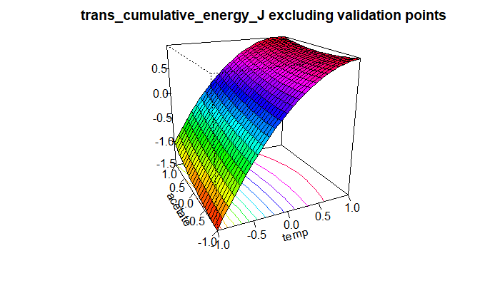

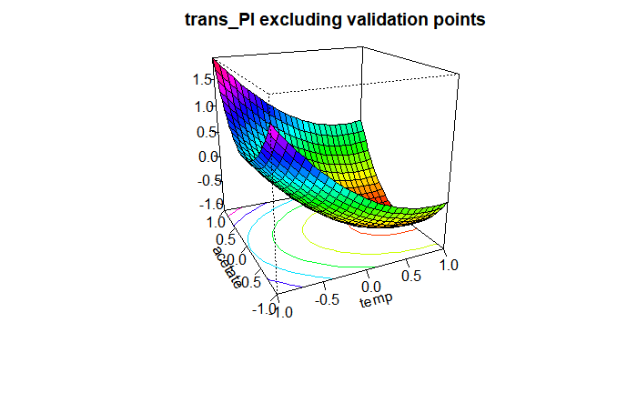

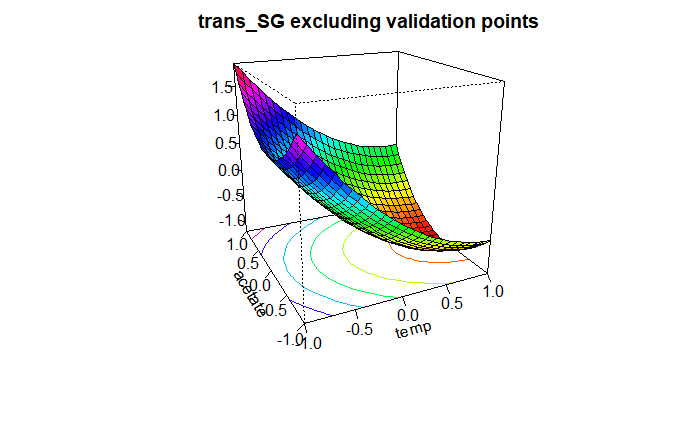

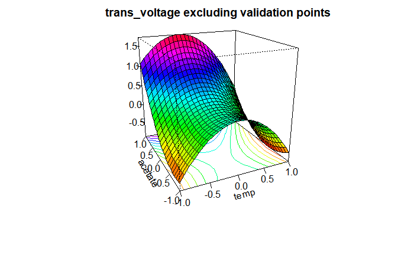

```r
# loop it and provide titles
for(i in sig_models){
 dfVariable$fitVariable[i] %>% unlist(recursive = FALSE) %>% structure(class = "lm") %>%
  persp(., ~ temp + acetate, col = rainbow(50), contours = "colors")
  title(main = paste(dfVariable$variable[i],"excluding validation points"))
}
```

Very nice! It may be worth coming back to this type of analysis (RSM and multivariate) after getting the sequencing data in - like Shannon’s index of bristles, RA of different otu’s, etc.

Take out non-significant RSM terms in models, re-visualize (do by turning coefficient estimate into zero? AIC selection?)

```r
# without validation points, then stepped with AIC
rsm_hist %>% select(mfc,type,temp,acetate,starts_with("trans")) %>% filter(type!="validation") %>% gather("variable","value",c(5:ncol(.))) %>% group_by(variable) %>% do(fitVariable = step(trace=0,lm(value ~ temp+acetate+I(temp^2)+I(acetate^2)+temp:acetate, data = .))) -> dfVariable

# get the coefficients by group in a tidy data_frame
dfVariableCoef = tidy(dfVariable, fitVariable)
dfVariableCoef
```

| variable | term | estimate | std.error | statistic | p.value |
| --- | --- | --- | --- | --- | --- |
| trans_ce | (Intercept) | -0.26286581 | 0.07731618 | -3.39988085 | 0.011444343 |
| trans_ce | temp | -0.02595008 | 0.07601666 | -0.34137356 | 0.742840487 |
| trans_ce | acetate | 0.03939221 | 0.07601666 | 0.51820490 | 0.620287047 |
| trans_ce | I(temp^2) | -0.14612015 | 0.11204179 | -1.30415756 | 0.233423364 |
| trans_ce | I(acetate^2) | 0.22794732 | 0.11204179 | 2.03448475 | 0.081372482 |
| trans_ce | temp:acetate | 0.10808929 | 0.09310101 | 1.16098939 | 0.283702651 |
| trans_charge_C | (Intercept) | 0.14775455 | 0.34013500 | 0.43439973 | 0.673221835 |
| trans_charge_C | I(temp^2) | -0.99888619 | 0.49290244 | -2.02653934 | 0.070209368 |
| trans_charge_C | I(acetate^2) | 0.93751472 | 0.49290244 | 1.90202896 | 0.086333071 |
| trans_cumulative_energy_J | (Intercept) | 0.32757703 | 0.26644938 | 1.22941561 | 0.247057852 |

[output cut: 31 more lines]

```r
# dfVariableCoef %>% filter(p.value<=.05,term != "(Intercept)")
# # get the predictions by group in a tidy data_frame
dfVariablePred = augment(dfVariable,fitVariable)
dfVariablePred
```

| variable | value | temp | acetate | I.temp.2. | I.acetate.2. | .fitted | .se.fit | .resid | .hat | .sigma | .cooksd | .std.resid |
| --- | --- | --- | --- | --- | --- | --- | --- | --- | --- | --- | --- | --- |
| trans_ce | -0.20700766 | -1 | -1 | 1 | 1 | -0.086391481 | 0.16552406 | -0.120616178 | 0.79022989 | 0.1699730 | 1.255906e+00 | -1.41432543 |
| trans_ce | -0.16050097 | -1 | 1 | 1 | 1 | -0.223785646 | 0.16552406 | 0.063284679 | 0.79022989 | 0.1930485 | 3.457350e-01 | 0.74206572 |
| trans_ce | -0.49952152 | 1 | -1 | 1 | 1 | -0.354470212 | 0.16552406 | -0.145051307 | 0.79022989 | 0.1540555 | 1.816308e+00 | -1.70084773 |
| trans_ce | -0.02065768 | 1 | 1 | 1 | 1 | -0.059507225 | 0.16552406 | 0.038849550 | 0.79022989 | 0.1981176 | 1.302921e-01 | 0.45554342 |
| trans_ce | 0.19135679 | 0 | -1 | 0 | 1 | -0.074310694 | 0.13090583 | 0.265667484 | 0.49425287 | 0.1311132 | 6.556002e-01 | 2.00626034 |
| trans_ce | -0.32570439 | -1 | 0 | 1 | 0 | -0.383035885 | 0.13090583 | 0.057331499 | 0.49425287 | 0.1984100 | 3.053155e-02 | 0.43295442 |
| trans_ce | -0.09766051 | 0 | 1 | 0 | 1 | 0.004473716 | 0.13090583 | -0.102134229 | 0.49425287 | 0.1923853 | 9.689579e-02 | -0.77129444 |
| trans_ce | -0.32873428 | 1 | 0 | 1 | 0 | -0.434936040 | 0.13090583 | 0.106201757 | 0.49425287 | 0.1916581 | 1.047673e-01 | 0.80201148 |
| trans_ce | -0.09280855 | 0 | 0 | 0 | 0 | -0.262865810 | 0.07731618 | 0.170057256 | 0.17241379 | 0.1860797 | 3.499579e-02 | 1.00393164 |
| trans_ce | -0.34398179 | 0 | 0 | 0 | 0 | -0.262865810 | 0.07731618 | -0.081115977 | 0.17241379 | 0.1977995 | 7.962295e-03 | -0.47886752 |

[output cut: 120 more lines]

```r
# get the summary statistics by group in a tidy data_frame
dfVariableSumm = glance(dfVariable, fitVariable)
dfVariableSumm
```

| variable | r.squared | adj.r.squared | sigma | statistic | p.value | df | logLik | AIC | BIC | deviance | df.residual |
| --- | --- | --- | --- | --- | --- | --- | --- | --- | --- | --- | --- |
| trans_ce | 0.4696804 | 0.09088066 | 0.1862020 | 1.239917 | 0.383168636 | 6 | 7.429553 | -0.8591066 | 3.095539 | 0.2426984 | 7 |
| trans_charge_C | 0.3589976 | 0.23079718 | 0.8191536 | 2.800283 | 0.108217654 | 3 | -14.147545 | 36.2950896 | 38.554887 | 6.7101254 | 10 |
| trans_cumulative_energy_J | 0.6240390 | 0.54884680 | 0.7049588 | 8.299252 | 0.007511280 | 3 | -12.195826 | 32.3916525 | 34.651450 | 4.9696691 | 10 |
| trans_cycle_5_energy_J | 0.3568530 | 0.22822355 | 0.8364217 | 2.774272 | 0.110040199 | 3 | -14.418743 | 36.8374861 | 39.097284 | 6.9960133 | 10 |
| trans_delta_cod_mg_L | 0.5200180 | 0.28002704 | 0.8576717 | 2.166823 | 0.163478480 | 5 | -13.294459 | 38.5889180 | 41.978614 | 5.8848054 | 8 |
| trans_delta_cod_mg_L_day | 0.5200180 | 0.28002704 | 0.8576717 | 2.166823 | 0.163478480 | 5 | -13.294459 | 38.5889180 | 41.978614 | 5.8848054 | 8 |
| trans_live_dead | 0.3972114 | 0.34241246 | 0.8432990 | 7.248521 | 0.020942618 | 2 | -15.144712 | 36.2894235 | 37.984272 | 7.8226857 | 11 |
| trans_PI | 0.8779134 | 0.81687010 | 0.4391602 | 14.381814 | 0.001002323 | 5 | -4.592816 | 21.1856315 | 24.575328 | 1.5428932 | 8 |
| trans_SG | 0.8521265 | 0.77818969 | 0.4860338 | 11.525070 | 0.002107916 | 5 | -5.911199 | 23.8223970 | 27.212093 | 1.8898311 | 8 |
| trans_voltage | 0.6442865 | 0.52571533 | 0.5919037 | 5.433754 | 0.020784566 | 4 | -9.238642 | 28.4772831 | 31.302030 | 3.1531494 | 9 |

```r
# get all significant models
dfVariableCoef %>% filter(p.value<=.05,term != "(Intercept)") %>% select(variable) %>% unique() %>% as.matrix() %>% match(.,dfVariable$variable) -> sig_models
dfVariable$variable[sig_models]
```

```
[1] "trans_cumulative_energy_J" "trans_live_dead"           "trans_PI"                  "trans_SG"                  "trans_voltage"
```

[output not shown]

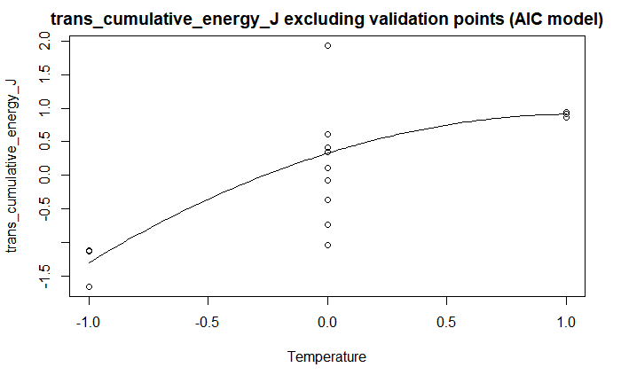

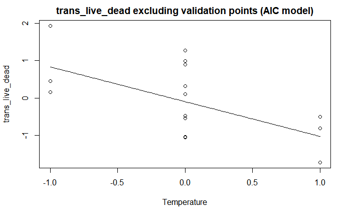

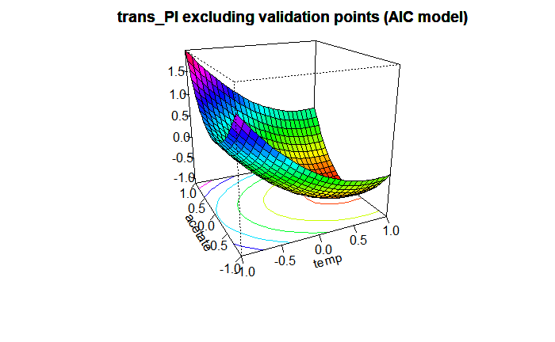

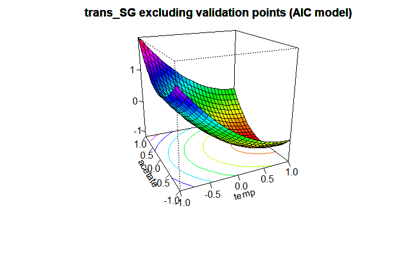

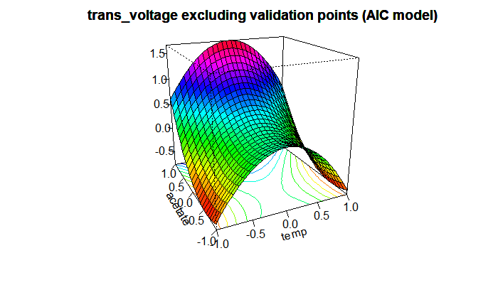

```r
# loop it and provide titles - looks like it doesn't know what to do when acetate coefficients are undefined
alternativeFunction <- function(){
    newdat = data.frame(temp = seq(min(rsm_hist$temp),max(rsm_hist$temp),length.out = 100))
  newdat$pred = predict(model, newdata = newdat)
  plot(unlist(rsm_hist[dfVariable$variable[i]]) ~ temp, data = rsm_hist, main = paste(dfVariable$variable[i],"excluding validation points (AIC model)"),xlab="Temperature",ylab=dfVariable$variable[i])
  with(newdat, lines(x = temp, y = pred))
    }
for(i in sig_models){
  dfVariable$fitVariable[i] %>% unlist(recursive = FALSE) %>% structure(class = "lm") -> model
t <- try(
  persp(model, ~ temp + acetate, col = rainbow(50), contours = "colors", main = paste(dfVariable$variable[i],"excluding validation points (AIC model)")))
if("try-error" %in% class(t))
  alternativeFunction()
}
```

How well do each of these models predict the validation points?

```r
rsm_hist %>% select(mfc,type,temp,acetate,dfVariable$variable[sig_models])  %>% filter(type=="validation") -> new.data
#Try with one model
# predict(dfVariable$fitVariable[3],newdata = new.data, interval = "predict")
#Try with all models
rsm_hist %>% select(mfc,type,temp,acetate,dfVariable$variable[sig_models])  %>% filter(type=="validation") %>% gather("variable","value",c(5:ncol(.))) %>% group_by(variable) %>%
  bind_cols(.,data.frame(do.call(rbind, predict(dfVariable$fitVariable[sig_models],newdata = new.data, interval = "predict")))) %>%    mutate(good_prediction = value>lwr & value<upr)
```

| mfc | type | temp | acetate | variable | value | fit | lwr | upr | good_prediction |
| --- | --- | --- | --- | --- | --- | --- | --- | --- | --- |
| 14 | validation | 0 | 0.5 | trans_cumulative_energy_J | -0.7411187 | 0.32757703 | -1.3516212 | 2.0067752 | TRUE |
| 15 | validation | 0 | 0.5 | trans_cumulative_energy_J | -0.3703279 | 0.32757703 | -1.3516212 | 2.0067752 | TRUE |
| 14 | validation | 0 | 0.5 | trans_live_dead | 0.9000919 | -0.09342541 | -2.0195796 | 1.8327288 | TRUE |
| 15 | validation | 0 | 0.5 | trans_live_dead | 0.3144384 | -0.09342541 | -2.0195796 | 1.8327288 | TRUE |
| 14 | validation | 0 | 0.5 | trans_PI | 0.9599870 | -0.38048386 | -1.4828848 | 0.7219170 | FALSE |
| 15 | validation | 0 | 0.5 | trans_PI | -0.6585916 | -0.38048386 | -1.4828848 | 0.7219170 | TRUE |
| 14 | validation | 0 | 0.5 | trans_SG | 0.9813402 | -0.33131911 | -1.5513845 | 0.8887463 | FALSE |
| 15 | validation | 0 | 0.5 | trans_SG | -0.4880631 | -0.33131911 | -1.5513845 | 0.8887463 | TRUE |
| 14 | validation | 0 | 0.5 | trans_voltage | -1.9206845 | 0.91384162 | -0.5437314 | 2.3714147 | FALSE |
| 15 | validation | 0 | 0.5 | trans_voltage | -0.9109789 | 0.91384162 | -0.5437314 | 2.3714147 | FALSE |

What are the optimal conditions for each response surface? Local vs. global? Inside or outside design space?

```r
df <- as_tibble(list(model=NA,temp=NA,acetate=NA,value=NA,maxmin=NA,locglo=NA))
newdat = data.frame(temp = rep(seq(min(rsm_hist$temp),max(rsm_hist$temp),length.out = 1000),each=1000))
newdat$acetate = rep(seq(min(rsm_hist$acetate),max(rsm_hist$acetate),length.out = 1000),times = 1000)


for(i in sig_models){
  dfVariable$fitVariable[i] %>% unlist(recursive = FALSE) %>% structure(class = "lm") -> model

  newdat$pred = predict(model, newdata = newdat)

  as_tibble(list(model=dfVariable$variable[i],temp=newdat$temp[which.min(newdat$pred)],acetate=newdat$acetate[which.min(newdat$pred)],value=min(newdat$pred),maxmin="min",locglo="loc")) %>% bind_rows(df,.) -> df

 bind_rows(df,as_tibble(list(model=dfVariable$variable[i],temp=newdat$temp[which.max(newdat$pred)],acetate=newdat$acetate[which.max(newdat$pred)],value=max(newdat$pred),maxmin="max",locglo="loc"))            ) ->df

}
df[-1,]->df
df$acetate[1:4] <- NA
df
```

| model | temp | acetate | value | maxmin | locglo |
| --- | --- | --- | --- | --- | --- |
| trans_cumulative_energy_J | -1.000000000 | NA | -1.3044888 | min | loc |
| trans_cumulative_energy_J | 1.000000000 | NA | 0.9106246 | max | loc |
| trans_live_dead | 1.000000000 | NA | -1.0203207 | min | loc |
| trans_live_dead | -1.000000000 | NA | 0.8334699 | max | loc |
| trans_PI | 0.799799800 | -0.1091091 | -1.1375402 | min | loc |
| trans_PI | -1.000000000 | 1.0000000 | 1.9530637 | max | loc |
| trans_SG | 0.995995996 | -0.1411411 | -1.1990364 | min | loc |
| trans_SG | -1.000000000 | 1.0000000 | 1.9691878 | max | loc |
| trans_voltage | -1.000000000 | -0.5835836 | -0.7992408 | min | loc |
| trans_voltage | -0.001001001 | 1.0000000 | 1.6569994 | max | loc |

What about the global max mins? This has to be done manually because of the difference in models. Note: this method doesn’t work for interaction terms.

| model | temp | acetate | maxmin | locglo | value |
| --- | --- | --- | --- | --- | --- |
| trans_cumulative_energy_J | 1.055803081 | NA | max | glo | 0.9122579 |
| trans_PI | 0.799314417 | -0.1087258 | min | glo | -1.1375405 |
| trans_SG | 0.995727787 | -0.1421182 | min | glo | -1.1990373 |
| trans_voltage | 0.000000000 | -0.5840278 | max | glo | 0.2592091 |
| trans_cumulative_energy_J | -1.000000000 | NA | min | loc | -1.3044888 |
| trans_cumulative_energy_J | 1.000000000 | NA | max | loc | 0.9106246 |
| trans_live_dead | 1.000000000 | NA | min | loc | -1.0203207 |
| trans_live_dead | -1.000000000 | NA | max | loc | 0.8334699 |
| trans_PI | 0.799799800 | -0.1091091 | min | loc | -1.1375402 |
| trans_PI | -1.000000000 | 1.0000000 | max | loc | 1.9530637 |

[output cut: 4 more lines]

What does the DNA analysis look like?